# Test9

## General Introduction

This test is designed to achieve contrast invariant response in spatially structured networks with synaptic plasticity.

This is based on the results shown in the Bernaez-Timon et al., manuscript (in preparation)

The features tested are : Distance Connectivity, SpatialGaussianStimulus, PowerLawSynapse and Heatmap recording.

Warning: The simulations can take hours to run.

This Live Script runs with Matlab

## Figures

%% Import Data

base_path = 'C:/Users/ekelmansp/Documents';

project_name1 = 'Test9A';%For the simulation at high input level. project_name is an identifier of the folder(s) containing the simulation data. The date suffix does not need to be included

project_name2 = 'Test9B';%For the simulation at low input level. Idem

%% Import data Simulation1

folderlist=dir([base_path filesep project_name1 '_20*']);

folder_name=folderlist(end).name;

cd([base_path filesep folder_name])

filename = [project_name1 '_HeatmapRate_Pop0.dat'];

delimiter = '\t';

startRow = 14;

formatEl='%f';

formatSpec=formatEl;%the first column is time;

for i=1:51

formatSpec=[formatSpec formatEl];%Each of the 500 recoreded neurons has 3 sources of inputs: recurrent E and I and feedforward

end

formatSpec=[formatSpec '%[^\n\r]'];

fileID = fopen(filename,'r');

dataArray = textscan(fileID, formatSpec, 'Delimiter', delimiter, 'EmptyValue' ,NaN,'HeaderLines' ,startRow-1, 'ReturnOnError', false, 'EndOfLine', '\r\n');

fclose(fileID);

Test9A = [dataArray{1:end-1}];

%% Import data Simulation2

folderlist=dir([base_path filesep project_name2 '_20*']);

folder_name=folderlist(end).name;

cd([base_path filesep folder_name])

filename = [project_name2 '_HeatmapRate_Pop0.dat'];

fileID = fopen(filename,'r');

dataArray = textscan(fileID, formatSpec, 'Delimiter', delimiter, 'EmptyValue' ,NaN,'HeaderLines' ,startRow-1, 'ReturnOnError', false, 'EndOfLine', '\r\n');

fclose(fileID);

Test9B = [dataArray{1:end-1}];

clearvars filename delimiter startRow formatSpec fileID dataArray ans folder_name formatEl i;

%% Analysis

figure

plot(linspace(-0.5,0.5,51),Test9A(end,2:end)./max(Test9A(end,2:end)),'LineWidth',2.5)

hold on

plot(linspace(-0.5,0.5,51),Test9B(end,2:end)./max(Test9B(end,2:end)),'--','LineWidth',2.5)

title('Check Contrast Invariance')

legend('Simulation1','Simulation2')

xlabel('Position')

ylabel('Normalized Firing rate')

set(gca,'FontSize',16)

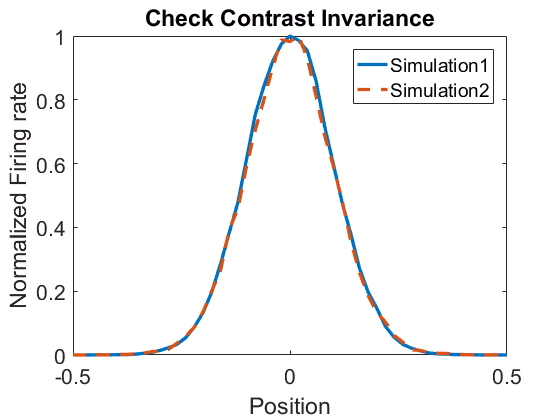

figure

plot([0 0.5 1],[0 max(Test9B(end,2:end)) max(Test9A(end,2:end))],'o:','LineWidth',2.5)

hold on

I=linspace(0,1,20);

nu_BS=zeros(size(I));

for i=1:length(I)

nu_BS(i)=max(SpaceBalanced([2 -10 5 -12],0.16,0.1,0.05,0.8,I(i),-0.5));

end

plot(I,nu_BS,'k','LineWidth',2.5)

title('Check nonlinearity')

xlabel('Input strength')

ylabel('Peak firing rate')

legend('Simulation','Balanced State Theory')

axis tight

set(gca,'FontSize',16)

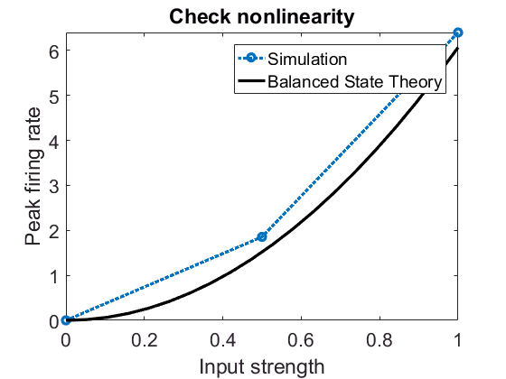

function [nu,X,nu_I]=SpaceBalanced(J,Sstim,SconE,pexE,fracE,mu,k)

Xlim=4*sqrt(Sstim^2-SconE^2);

X=[-1:0.02:1]*Xlim;

X=linspace(-Xlim,Xlim,1e4+1);

J=abs(J);

b=(J(2)-J(4))/(J(1)*J(4)-J(2)*J(3));

c=(J(1)-J(3))/(J(1)*J(4)-J(2)*J(3));

nu=mu*b*Sstim/(pexE*fracE*sqrt(Sstim^2-SconE^2)).*exp(-X.^2/(2*Sstim^2-2*SconE^2));

nu=nu.^(inv(1+k));

SconI=SconE;

pexI=pexE;

nu_I=mu*c*Sstim/(pexI*(1-fracE)*sqrt(Sstim^2-SconI^2)).*exp(-X.^2/(2*Sstim^2-2*SconI^2));

end

The first figure illustrates contrast invariance: the firing rate profiles have different amplitudes depending on the input srtength, but the normalized profiles are identical.

The second figure shows how the peak firing rate (at x=0) changes as a function of the input strength. Due to the power law synaptic plasticity rule, the network response is nonlinear as a function of the input strength. As a comparison, the theoretical solution from the balanced state theory follows the same trend.